# V2 Model, Decision Tree Classifier v. Logistic Regression

```python
import seaborn as sns
import pandas as pd
import numpy as np
import pprint
from sklearn.metrics import accuracy_score,confusion_matrix,precision_score,recall_score, r2_score, max_error
from sklearn.model_selection import train_test_split
from sklearn.linear_model import LogisticRegression
from sklearn.tree import DecisionTreeClassifier
from sklearn.ensemble import RandomForestClassifier
from sklearn.compose import ColumnTransformer
from sklearn.pipeline import make_pipeline,Pipeline
from sklearn.preprocessing import StandardScaler,OneHotEncoder
from sklearn.model_selection import cross_val_score,cross_validate
import matplotlib.pyplot as plt
from sklearn.impute import SimpleImputer
from sklearn import set_config
```

```python
df = pd.read_csv("healthcare-dataset-stroke-data.csv")
df.head()
```

|  | id | gender | age | hypertension | heart_disease | ever_married | work_type | Residence_type | avg_glucose_level | bmi | smoking_status | stroke |
| --- | --- | --- | --- | --- | --- | --- | --- | --- | --- | --- | --- | --- |
| 0 | 9046 | Male | 67.0 | 0 | 1 | Yes | Private | Urban | 228.69 | 36.6 | formerly smoked | 1 |
| 1 | 51676 | Female | 61.0 | 0 | 0 | Yes | Self-employed | Rural | 202.21 | NaN | never smoked | 1 |
| 2 | 31112 | Male | 80.0 | 0 | 1 | Yes | Private | Rural | 105.92 | 32.5 | never smoked | 1 |
| 3 | 60182 | Female | 49.0 | 0 | 0 | Yes | Private | Urban | 171.23 | 34.4 | smokes | 1 |
| 4 | 1665 | Female | 79.0 | 1 | 0 | Yes | Self-employed | Rural | 174.12 | 24.0 | never smoked | 1 |

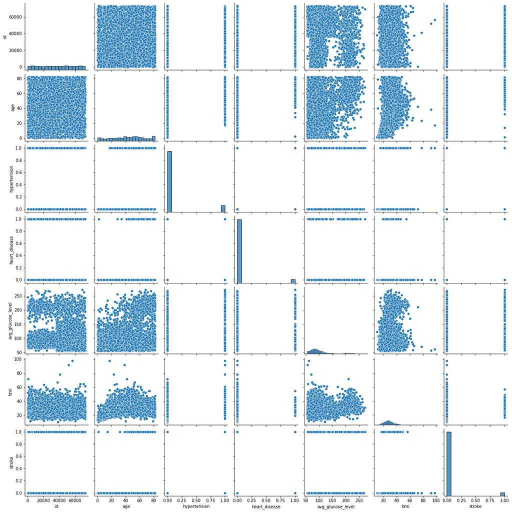

```python
sns.pairplot(df)
```

I am going to change some features to get a better model by:

- Setting just low or high glucose (1 or 0), based on above or below the median value of 'avg_glucose_level'
- Setting 'ever_married' Yes = 1, No = 0
- Setting reported 'gender' to a 1 or 0
- Fill in missing bmi values with the mean values of each gender

```python
# get glucose median for the target variable
p50 = df['avg_glucose_level'].median()
df['median_glucose'] = df['avg_glucose_level'].apply(lambda x: 1 if x< p50 else 0 )
df.head(10)
```

|  | id | gender | age | hypertension | heart_disease | ever_married | work_type | Residence_type | avg_glucose_level | bmi | smoking_status | stroke | median_glucose |
| --- | --- | --- | --- | --- | --- | --- | --- | --- | --- | --- | --- | --- | --- |
| 0 | 9046 | Male | 67.0 | 0 | 1 | Yes | Private | Urban | 228.69 | 36.6 | formerly smoked | 1 | 0 |
| 1 | 51676 | Female | 61.0 | 0 | 0 | Yes | Self-employed | Rural | 202.21 | NaN | never smoked | 1 | 0 |
| 2 | 31112 | Male | 80.0 | 0 | 1 | Yes | Private | Rural | 105.92 | 32.5 | never smoked | 1 | 0 |
| 3 | 60182 | Female | 49.0 | 0 | 0 | Yes | Private | Urban | 171.23 | 34.4 | smokes | 1 | 0 |
| 4 | 1665 | Female | 79.0 | 1 | 0 | Yes | Self-employed | Rural | 174.12 | 24.0 | never smoked | 1 | 0 |
| 5 | 56669 | Male | 81.0 | 0 | 0 | Yes | Private | Urban | 186.21 | 29.0 | formerly smoked | 1 | 0 |
| 6 | 53882 | Male | 74.0 | 1 | 1 | Yes | Private | Rural | 70.09 | 27.4 | never smoked | 1 | 1 |
| 7 | 10434 | Female | 69.0 | 0 | 0 | No | Private | Urban | 94.39 | 22.8 | never smoked | 1 | 0 |
| 8 | 27419 | Female | 59.0 | 0 | 0 | Yes | Private | Rural | 76.15 | NaN | Unknown | 1 | 1 |
| 9 | 60491 | Female | 78.0 | 0 | 0 | Yes | Private | Urban | 58.57 | 24.2 | Unknown | 1 | 1 |

```python
# Create dummy variables for the categorical variables
categorical_columns = ['ever_married','gender']
df_dummies = pd.get_dummies(df,columns=categorical_columns,drop_first=True,)
df_dummies
```

|  | id | age | hypertension | heart_disease | work_type | Residence_type | avg_glucose_level | bmi | smoking_status | stroke | median_glucose | ever_married_Yes | gender_Male | gender_Other |
| --- | --- | --- | --- | --- | --- | --- | --- | --- | --- | --- | --- | --- | --- | --- |
| 0 | 9046 | 67.0 | 0 | 1 | Private | Urban | 228.69 | 36.6 | formerly smoked | 1 | 0 | 1 | 1 | 0 |
| 1 | 51676 | 61.0 | 0 | 0 | Self-employed | Rural | 202.21 | NaN | never smoked | 1 | 0 | 1 | 0 | 0 |
| 2 | 31112 | 80.0 | 0 | 1 | Private | Rural | 105.92 | 32.5 | never smoked | 1 | 0 | 1 | 1 | 0 |
| 3 | 60182 | 49.0 | 0 | 0 | Private | Urban | 171.23 | 34.4 | smokes | 1 | 0 | 1 | 0 | 0 |
| 4 | 1665 | 79.0 | 1 | 0 | Self-employed | Rural | 174.12 | 24.0 | never smoked | 1 | 0 | 1 | 0 | 0 |
| ... | ... | ... | ... | ... | ... | ... | ... | ... | ... | ... | ... | ... | ... | ... |
| 5105 | 18234 | 80.0 | 1 | 0 | Private | Urban | 83.75 | NaN | never smoked | 0 | 1 | 1 | 0 | 0 |
| 5106 | 44873 | 81.0 | 0 | 0 | Self-employed | Urban | 125.20 | 40.0 | never smoked | 0 | 0 | 1 | 0 | 0 |
| 5107 | 19723 | 35.0 | 0 | 0 | Self-employed | Rural | 82.99 | 30.6 | never smoked | 0 | 1 | 1 | 0 | 0 |
| 5108 | 37544 | 51.0 | 0 | 0 | Private | Rural | 166.29 | 25.6 | formerly smoked | 0 | 0 | 1 | 1 | 0 |
| 5109 | 44679 | 44.0 | 0 | 0 | Govt_job | Urban | 85.28 | 26.2 | Unknown | 0 | 1 | 1 | 0 | 0 |

5110 rows × 14 columns

```python
female_mean_bmi = df_dummies.groupby('gender_Male')['bmi'].mean()[0]
male_mean_bmi = df_dummies.groupby('gender_Male')['bmi'].mean()[1]
# Just checking:
print(female_mean_bmi)
print(male_mean_bmi)
```

```
29.063457556935866
28.647936350074616
```

```python
m1 = (df_dummies['gender_Male'] == 0)  #female case
m2 = (df_dummies['gender_Male'] == 1) #male case
df_dummies.loc[m1,'bmi'] = df_dummies.loc[m1,'bmi'].fillna(female_mean_bmi)
df_dummies.loc[m2,'bmi'] = df_dummies.loc[m2,'bmi'].fillna(male_mean_bmi)
```

```python
# Let's see if that has filled in the NaN 'bmi' values (second row had a NaN before):
df_dummies.head()
```

|  | id | age | hypertension | heart_disease | work_type | Residence_type | avg_glucose_level | bmi | smoking_status | stroke | median_glucose | ever_married_Yes | gender_Male | gender_Other |
| --- | --- | --- | --- | --- | --- | --- | --- | --- | --- | --- | --- | --- | --- | --- |
| 0 | 9046 | 67.0 | 0 | 1 | Private | Urban | 228.69 | 36.600000 | formerly smoked | 1 | 0 | 1 | 1 | 0 |
| 1 | 51676 | 61.0 | 0 | 0 | Self-employed | Rural | 202.21 | 29.063458 | never smoked | 1 | 0 | 1 | 0 | 0 |
| 2 | 31112 | 80.0 | 0 | 1 | Private | Rural | 105.92 | 32.500000 | never smoked | 1 | 0 | 1 | 1 | 0 |
| 3 | 60182 | 49.0 | 0 | 0 | Private | Urban | 171.23 | 34.400000 | smokes | 1 | 0 | 1 | 0 | 0 |
| 4 | 1665 | 79.0 | 1 | 0 | Self-employed | Rural | 174.12 | 24.000000 | never smoked | 1 | 0 | 1 | 0 | 0 |

I actually want to try a Decision Tree model first for comparison:

```python
train_cols = ['age','hypertension','heart_disease','bmi'] +['ever_married_Yes','gender_Male','gender_Other']
target = ['stroke']
X = df_dummies[train_cols]
y = df_dummies[target]

X_train, X_test, y_train, y_test = train_test_split(X,y, test_size=0.30, random_state=42)
```

```python
clf = DecisionTreeClassifier(max_leaf_nodes=10)
clf.fit(X_train,y_train.values.ravel())
```

```
DecisionTreeClassifier(max_leaf_nodes=10)
```

```python
y_true = y_test
y_preds = clf.predict(X_test)

accuracy = accuracy_score(y_true,y_preds)
precision = precision_score(y_true,y_preds)
recall = recall_score(y_true,y_preds)

print('accuracy',accuracy,'precision',precision,'recall',recall)

print("confusion matrix")
confusion_matrix(y_true,y_preds)
```

```
accuracy 0.9373776908023483 precision 0.1111111111111111 recall 0.011235955056179775
confusion matrix
```

```
array([[1436,    8],
       [  88,    1]])
```

```python
X_train_test, X_val, y_train_test, y_val = train_test_split(X,y, test_size=0.20, random_state=42)
```

```python
#Just checking cross-validated runs:
clf = DecisionTreeClassifier()
n_folds = 5
scores = cross_validate(clf, X_train_test, y_train_test, cv=n_folds,scoring=('accuracy','precision','recall'))
pprint.pprint(scores)
print("\n")
print("mean accuracy:",scores['test_accuracy'].mean(),
      "mean precision:",scores['test_precision'].mean(),
      "mean recall:", scores['test_recall'].mean())
```

```
{'fit_time': array([0.0073719 , 0.00913   , 0.00763702, 0.00659895, 0.006845  ]),
 'score_time': array([0.00362706, 0.00531673, 0.00422096, 0.00299025, 0.00319481]),
 'test_accuracy': array([0.91075795, 0.92665037, 0.91564792, 0.90942472, 0.92656059]),
 'test_precision': array([0.07142857, 0.04166667, 0.13953488, 0.08888889, 0.20512821]),
 'test_recall': array([0.08108108, 0.02631579, 0.15789474, 0.10810811, 0.21621622])}


mean accuracy: 0.917808309367266 mean precision: 0.10932944316665245 mean recall: 0.11792318634423897
```

- It looks like the Decision Tree Classifier is roughly 91-94% accurate, with low precision and recall metrics.

Now let's check how a Logistic Regression model will do with the newly modified features:

```python
# Logistic Regression model:
clf = LogisticRegression(penalty='l2',C=1.0,random_state=0)
scores = cross_validate(clf, X_train_test, y_train_test,scoring=('accuracy','precision','recall'))
pprint.pprint(scores)
print("\n")
print("mean accuracy:",scores['test_accuracy'].mean(),
      "mean precision:",scores['test_precision'].mean(),
      "mean recall:", scores['test_recall'].mean())
```

```
{'fit_time': array([0.02931094, 0.02477813, 0.02675509, 0.02817416, 0.02182293]),
 'score_time': array([0.00475597, 0.00384998, 0.00460219, 0.00380206, 0.00362206]),
 'test_accuracy': array([0.95476773, 0.95354523, 0.95354523, 0.95471236, 0.95471236]),
 'test_precision': array([0., 0., 0., 0., 0.]),
 'test_recall': array([0., 0., 0., 0., 0.])}


mean accuracy: 0.9542565830622498 mean precision: 0.0 mean recall: 0.0
```

It looks like the Log Reg model is not that much better than the DTC with these features (only 95% accuracy...)

At this point I want to try to improve my model by adjusting more inputs:

- scale some of the numerical variables
- include categorical variables
- Actually impute mean values into missing 'bmi' values

```python
#Scale numerical variables:
df_dummies['age_scaled'] = (df_dummies['age'] - df_dummies['age'].mean())/df_dummies['age'].std()
df_dummies['bmi_scaled'] = (df_dummies['bmi'] - df_dummies['bmi'].mean())/df_dummies['bmi'].std()
df_dummies['avg_glucose_level_scaled'] = (df_dummies['avg_glucose_level'] - df_dummies['avg_glucose_level'].mean())/df_dummies['avg_glucose_level'].std()
df_dummies.head()
```

|  | id | age | hypertension | heart_disease | work_type | Residence_type | avg_glucose_level | bmi | smoking_status | stroke | median_glucose | ever_married_Yes | gender_Male | gender_Other | age_scaled | bmi_scaled | avg_glucose_level_scaled |
| --- | --- | --- | --- | --- | --- | --- | --- | --- | --- | --- | --- | --- | --- | --- | --- | --- | --- |
| 0 | 9046 | 67.0 | 0 | 1 | Private | Urban | 228.69 | 36.600000 | formerly smoked | 1 | 0 | 1 | 1 | 0 | 1.051331 | 1.001350 | 2.706111 |
| 1 | 51676 | 61.0 | 0 | 0 | Self-employed | Rural | 202.21 | 29.063458 | never smoked | 1 | 0 | 1 | 0 | 0 | 0.785993 | 0.022341 | 2.121351 |
| 2 | 31112 | 80.0 | 0 | 1 | Private | Rural | 105.92 | 32.500000 | never smoked | 1 | 0 | 1 | 1 | 0 | 1.626231 | 0.468753 | -0.005028 |
| 3 | 60182 | 49.0 | 0 | 0 | Private | Urban | 171.23 | 34.400000 | smokes | 1 | 0 | 1 | 0 | 0 | 0.255317 | 0.715566 | 1.437217 |
| 4 | 1665 | 79.0 | 1 | 0 | Self-employed | Rural | 174.12 | 24.000000 | never smoked | 1 | 0 | 1 | 0 | 0 | 1.582008 | -0.635411 | 1.501038 |

```python
# Adding onto the dummy variables to include all of the categorical variables:
categorical_columns = ['work_type','Residence_type', 'smoking_status']
df_dummies2 = pd.get_dummies(df_dummies,columns=categorical_columns,drop_first=True,)
df_dummies2
```

|  | id | age | hypertension | heart_disease | avg_glucose_level | bmi | stroke | median_glucose | ever_married_Yes | gender_Male | ... | bmi_scaled | avg_glucose_level_scaled | work_type_Never_worked | work_type_Private | work_type_Self-employed | work_type_children | Residence_type_Urban | smoking_status_formerly smoked | smoking_status_never smoked | smoking_status_smokes |
| --- | --- | --- | --- | --- | --- | --- | --- | --- | --- | --- | --- | --- | --- | --- | --- | --- | --- | --- | --- | --- | --- |
| 0 | 9046 | 67.0 | 0 | 1 | 228.69 | 36.600000 | 1 | 0 | 1 | 1 | ... | 1.001350 | 2.706111 | 0 | 1 | 0 | 0 | 1 | 1 | 0 | 0 |
| 1 | 51676 | 61.0 | 0 | 0 | 202.21 | 29.063458 | 1 | 0 | 1 | 0 | ... | 0.022341 | 2.121351 | 0 | 0 | 1 | 0 | 0 | 0 | 1 | 0 |
| 2 | 31112 | 80.0 | 0 | 1 | 105.92 | 32.500000 | 1 | 0 | 1 | 1 | ... | 0.468753 | -0.005028 | 0 | 1 | 0 | 0 | 0 | 0 | 1 | 0 |
| 3 | 60182 | 49.0 | 0 | 0 | 171.23 | 34.400000 | 1 | 0 | 1 | 0 | ... | 0.715566 | 1.437217 | 0 | 1 | 0 | 0 | 1 | 0 | 0 | 1 |
| 4 | 1665 | 79.0 | 1 | 0 | 174.12 | 24.000000 | 1 | 0 | 1 | 0 | ... | -0.635411 | 1.501038 | 0 | 0 | 1 | 0 | 0 | 0 | 1 | 0 |
| ... | ... | ... | ... | ... | ... | ... | ... | ... | ... | ... | ... | ... | ... | ... | ... | ... | ... | ... | ... | ... | ... |
| 5105 | 18234 | 80.0 | 1 | 0 | 83.75 | 29.063458 | 0 | 1 | 1 | 0 | ... | 0.022341 | -0.494609 | 0 | 1 | 0 | 0 | 1 | 0 | 1 | 0 |
| 5106 | 44873 | 81.0 | 0 | 0 | 125.20 | 40.000000 | 0 | 0 | 1 | 0 | ... | 1.443015 | 0.420734 | 0 | 0 | 1 | 0 | 1 | 0 | 1 | 0 |
| 5107 | 19723 | 35.0 | 0 | 0 | 82.99 | 30.600000 | 0 | 1 | 1 | 0 | ... | 0.221940 | -0.511393 | 0 | 0 | 1 | 0 | 0 | 0 | 1 | 0 |
| 5108 | 37544 | 51.0 | 0 | 0 | 166.29 | 25.600000 | 0 | 0 | 1 | 1 | ... | -0.427568 | 1.328127 | 0 | 1 | 0 | 0 | 0 | 1 | 0 | 0 |
| 5109 | 44679 | 44.0 | 0 | 0 | 85.28 | 26.200000 | 0 | 1 | 1 | 0 | ... | -0.349627 | -0.460822 | 0 | 0 | 0 | 0 | 1 | 0 | 0 | 0 |

5110 rows × 22 columns

```python
#Use Simple Imputer for the means. I needed to replace the original bmi values first.
df_dummies2['bmi'] = df['bmi']
imp_mean = SimpleImputer(missing_values=np.nan, strategy='mean')
#imp_mean.fit_transform(df_dummies2)
imp_mean = imp_mean.fit(df_dummies2[['bmi']])
df_dummies2['bmi'] = imp_mean.transform(df_dummies2[['bmi']])
df_dummies2.head()
```

|  | id | age | hypertension | heart_disease | avg_glucose_level | bmi | stroke | median_glucose | ever_married_Yes | gender_Male | ... | bmi_scaled | avg_glucose_level_scaled | work_type_Never_worked | work_type_Private | work_type_Self-employed | work_type_children | Residence_type_Urban | smoking_status_formerly smoked | smoking_status_never smoked | smoking_status_smokes |
| --- | --- | --- | --- | --- | --- | --- | --- | --- | --- | --- | --- | --- | --- | --- | --- | --- | --- | --- | --- | --- | --- |
| 0 | 9046 | 67.0 | 0 | 1 | 228.69 | 36.600000 | 1 | 0 | 1 | 1 | ... | 1.001350 | 2.706111 | 0 | 1 | 0 | 0 | 1 | 1 | 0 | 0 |
| 1 | 51676 | 61.0 | 0 | 0 | 202.21 | 28.893237 | 1 | 0 | 1 | 0 | ... | 0.022341 | 2.121351 | 0 | 0 | 1 | 0 | 0 | 0 | 1 | 0 |
| 2 | 31112 | 80.0 | 0 | 1 | 105.92 | 32.500000 | 1 | 0 | 1 | 1 | ... | 0.468753 | -0.005028 | 0 | 1 | 0 | 0 | 0 | 0 | 1 | 0 |
| 3 | 60182 | 49.0 | 0 | 0 | 171.23 | 34.400000 | 1 | 0 | 1 | 0 | ... | 0.715566 | 1.437217 | 0 | 1 | 0 | 0 | 1 | 0 | 0 | 1 |
| 4 | 1665 | 79.0 | 1 | 0 | 174.12 | 24.000000 | 1 | 0 | 1 | 0 | ... | -0.635411 | 1.501038 | 0 | 0 | 1 | 0 | 0 | 0 | 1 | 0 |

5 rows × 22 columns

```python
#Selecting the training data with all of the new scaled / modified categorical columns:
smoking = ['smoking_status_formerly smoked','smoking_status_never smoked','smoking_status_smokes']
existing_conditions = ['hypertension','heart_disease']
health_metrics = ['bmi_scaled','age_scaled','avg_glucose_level_scaled']
other_factors = ['ever_married_Yes','gender_Male','gender_Other','work_type_Never_worked','work_type_Private','work_type_Self-employed','work_type_children','Residence_type_Urban']

train_cols = smoking+existing_conditions+health_metrics+other_factors
#train_cols = smoking+existing_conditions

target = ['stroke']
#target = ['median_glucose']

X = df_dummies2[train_cols]
y = df_dummies2[target]

X_train, X_test, y_train, y_test = train_test_split(X,y, test_size=0.30, random_state=42)
```

```python
X_train_test, X_val, y_train_test, y_val = train_test_split(X,y, test_size=0.20, random_state=42)
```

```python
clf = LogisticRegression(penalty='l2',C=1.0,random_state=0)
scores = cross_validate(clf, X_train_test, y_train_test,scoring=('accuracy','precision','recall'))
pprint.pprint(scores)
print("\n")
print("mean accuracy:",scores['test_accuracy'].mean(),
      "mean precision:",scores['test_precision'].mean(),
      "mean recall:", scores['test_recall'].mean())
```

```
{'fit_time': array([0.01805091, 0.01376414, 0.01320291, 0.01181102, 0.01308489]),
 'score_time': array([0.00365996, 0.00358105, 0.00370002, 0.00375605, 0.00355506]),
 'test_accuracy': array([0.95476773, 0.95354523, 0.95354523, 0.95471236, 0.95471236]),
 'test_precision': array([0.5, 0. , 0. , 0. , 0. ]),
 'test_recall': array([0.02702703, 0.        , 0.        , 0.        , 0.        ])}


mean accuracy: 0.9542565830622498 mean precision: 0.1 mean recall: 0.005405405405405406
```